# Part II - Ford GoBike Data Explanation

## by Leslie Narh

## Investigation Overview

In this investigation, I wanted to look at the uptake of the service among the different user types and gender . I was also interested in time of day and day of the week when most trips happen as well as the trip duration.

## Dataset Overview

Original dataset had 183,412 rows/enteries and 16 columns/features. After data wrangling and cleaning of the Ford I had **171,542 rows/enteries** and **7 columns/features** for my analysis.

- `start_time` (in datetime format)
- `end_time` (in datetime format)
- `duration_min`(minutes)
- `bike_share_for_all_trip` (in bool format)
- `user_type`(subscriber or customer)
- `member_gender`
- `age`

## How are trips distributed over specific times in a day?

Most rides are are in high demand from Monday - Friday, from 8am - 5pm with a slight dip on Mondays and Fridays. Demand drops significantly on the weekends. This indicates the service is predominantly used by residents to commute to and from work.

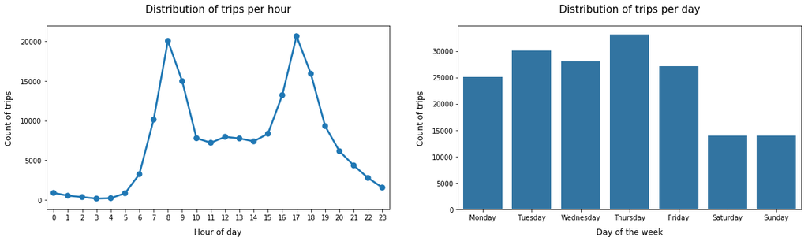

## Trips per hour for each user type

Subscriber demand in bike rides reveal a significant peak at 8am and 5pm. The demand drops after 8am and 5pm. The same trend can be seen in the Customer user type, but with a less significant peak at 8am and 5pm. Further research from the Bay Wheels website indicates customers are casual users. This is evident in their usage trend as they could be making one-time trips and not regular users like the subscribers.

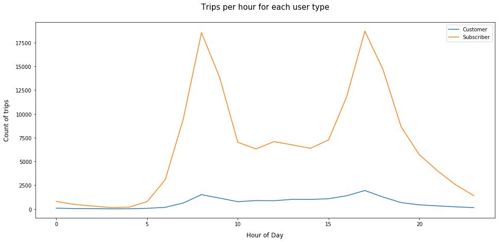

## Trips per day for each user type

For subscribers, bike rides demand are high during the working day and significantly low on the weekends. There is very little variation in the trend for customers. Demand dips over the weekend for subscribers and slightly on Monday and Friday. This analysis coupled with my previous line plots indicate the bike service is patronised typically by the working class.

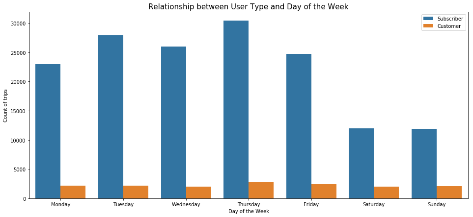

## Trip duration for each gender type

From the daily analysis,females and other gender tend to take a longer time in reaching their destination. Female trips are the longest on Monday, Thursday and Saturday. This could mean the male gender is probably faster or are usually starting trips late thus tend to rush.

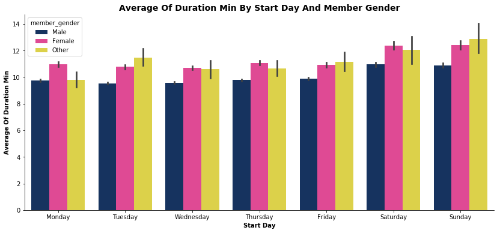

## Trips duration for each user type

Subscriber trip duration is almost flat through out the week. I have 2 hypothesis from this analysis

1. Subscribers use this service frequently,thus they are accustomed to the route and are able to manuever swiftly to their destinations.
2. Subscribers are benefitting from a fixed price or fee waiver on the first 10 minutes. Thus, motivated to keep their trips within this scope

There is a significant increase in trip duration for customers over the weekend. Customers are usually riding for fun or making a lot spontaneous trips during this period.

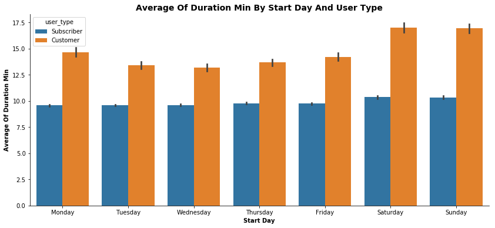